# Schneider Electric Machine Learning Project

[figure not shown]

## Schneider Electric Machine Learning Project

**PRASAD JADHAV**

```python
import pandas as pd
import numpy as np

import matplotlib.pyplot as plt
import seaborn as sns
```

```python
import warnings
warnings.filterwarnings('ignore')
```

```python
df = pd.read_csv('schneider_electric_dataset.csv')
pd.set_option('display.max_columns',20)
print(df.shape)
```

```
(100000, 20)
```

```python
df.head()
```

|  | Product_ID | Category | Technical_Specifications | Sales | Region | Customer_Rating | Fault_Flag | Maintenance_Records | Price | Date | Energy_Consumption | Sensor_Readings | Warranty_Expiry | Lead_Time | Supply_Chain_Risk | Demand_Variation | Promotions_Applied | Competitor_Price | Return_Flag | User_Demographics |
| --- | --- | --- | --- | --- | --- | --- | --- | --- | --- | --- | --- | --- | --- | --- | --- | --- | --- | --- | --- | --- |
| 0 | 1 | Power Meter | {"voltage": "220V", "power": "50W"} | 4851 | North | 3.62 | No | 5 | 2009.28 | 2020-01-01 00:00:00 | 468.20 | {"temperature": 30, "pressure": 1.2} | 24 | 11 | 0.13 | 45.39 | Yes | 2990.56 | Yes | Enterprise |
| 1 | 2 | Switch | {"voltage": "220V", "power": "50W"} | 556 | West | 1.70 | No | 2 | 1899.78 | 2020-01-01 01:00:00 | 133.46 | {"temperature": 40, "pressure": 1.5} | 9 | 15 | 0.40 | 47.75 | Yes | 1358.28 | Yes | Individual |
| 2 | 3 | Switch | {"voltage": "110V", "power": "30W"} | 4713 | East | 1.80 | Yes | 0 | 2271.00 | 2020-01-01 02:00:00 | 414.33 | {"temperature": 40, "pressure": 1.5} | 7 | 10 | 0.94 | 46.11 | No | 2160.00 | No | Small Business |
| 3 | 4 | Relay | {"voltage": "220V", "power": "50W"} | 4499 | East | 3.46 | No | 2 | 1174.32 | 2020-01-01 03:00:00 | 170.97 | {"temperature": 40, "pressure": 1.5} | 26 | 18 | 0.08 | 11.98 | No | 2948.44 | Yes | Government |
| 4 | 5 | Switch | {"voltage": "110V", "power": "30W"} | 3704 | West | 4.59 | No | 7 | 3081.87 | 2020-01-01 04:00:00 | 115.83 | {"temperature": 40, "pressure": 1.5} | 30 | 19 | 0.06 | 35.71 | No | 4197.57 | Yes | Individual |

```python
df.tail()
```

|  | Product_ID | Category | Technical_Specifications | Sales | Region | Customer_Rating | Fault_Flag | Maintenance_Records | Price | Date | Energy_Consumption | Sensor_Readings | Warranty_Expiry | Lead_Time | Supply_Chain_Risk | Demand_Variation | Promotions_Applied | Competitor_Price | Return_Flag | User_Demographics |
| --- | --- | --- | --- | --- | --- | --- | --- | --- | --- | --- | --- | --- | --- | --- | --- | --- | --- | --- | --- | --- |
| 99995 | 99996 | Switch | {"voltage": "220V", "power": "50W"} | 3311 | West | 2.41 | Yes | 6 | 4651.82 | 2031-05-29 11:00:00 | 445.16 | {"temperature": 30, "pressure": 1.2} | 6 | 19 | 0.16 | 47.12 | Yes | 543.99 | Yes | Small Business |
| 99996 | 99997 | Switch | {"voltage": "220V", "power": "50W"} | 4178 | East | 4.82 | No | 2 | 3206.15 | 2031-05-29 12:00:00 | 292.51 | {"temperature": 30, "pressure": 1.2} | 3 | 11 | 0.70 | 32.99 | Yes | 4132.05 | Yes | Enterprise |
| 99997 | 99998 | Switch | {"voltage": "220V", "power": "50W"} | 4403 | West | 1.25 | Yes | 9 | 280.02 | 2031-05-29 13:00:00 | 300.55 | {"temperature": 30, "pressure": 1.2} | 9 | 5 | 0.79 | 4.98 | Yes | 2179.27 | No | Government |
| 99998 | 99999 | Switch | {"voltage": "110V", "power": "30W"} | 2154 | West | 4.65 | No | 7 | 4570.44 | 2031-05-29 14:00:00 | 279.96 | {"temperature": 30, "pressure": 1.2} | 16 | 2 | 0.23 | 23.90 | Yes | 2823.15 | No | Government |
| 99999 | 100000 | Switch | {"voltage": "220V", "power": "50W"} | 4157 | North | 1.58 | Yes | 8 | 2879.91 | 2031-05-29 15:00:00 | 382.38 | {"temperature": 40, "pressure": 1.5} | 3 | 11 | 0.21 | 18.29 | No | 1819.78 | Yes | Enterprise |

### Dataset Columns Overview

- Product_ID: Unique identifier for each product.
- Category: Product category (e.g., circuit breakers, switches).
- Technical_Specifications: JSON field containing specs (voltage, power rating, etc.).
- Sales: Historical sales data (number of units sold).
- Region: Sales region.
- Customer_Rating: Average customer ratings.
- Fault_Flag: Indicates if a product had a fault (Yes/No).
- Maintenance_Records: Number of maintenance events.
- Price: Product price.
- Date: Timestamp of sales/maintenance data.
- Energy_Consumption: Energy consumed by the product (kWh).
- Sensor_Readings: Data from product sensors (temperature, pressure, etc.).
- Warranty_Expiry: Time remaining on the product warranty (in months).
- Lead_Time: Delivery lead time (in days).
- Supply_Chain_Risk: Risk factor based on supply chain conditions.
- Demand_Variation: Month-to-month variation in demand.
- Promotions_Applied: Whether a promotion was applied (Yes/No).
- Competitor_Price: Price of a similar product by competitors.
- Return_Flag: Indicates if the product was returned (Yes/No).
- User_Demographics: Information about the purchasing company or customer (size, industry).

### Data Exploration

```python
df.info()
```

```
<class 'pandas.core.frame.DataFrame'>
RangeIndex: 100000 entries, 0 to 99999
Data columns (total 20 columns):
 #   Column                    Non-Null Count   Dtype
---  ------                    --------------   -----
 0   Product_ID                100000 non-null  int64
 1   Category                  100000 non-null  object
 2   Technical_Specifications  100000 non-null  object
 3   Sales                     100000 non-null  int64
 4   Region                    100000 non-null  object
 5   Customer_Rating           100000 non-null  float64
 6   Fault_Flag                100000 non-null  object
 7   Maintenance_Records       100000 non-null  int64
 8   Price                     100000 non-null  float64
 9   Date                      100000 non-null  object
 10  Energy_Consumption        100000 non-null  float64
 11  Sensor_Readings           100000 non-null  object
 12  Warranty_Expiry           100000 non-null  int64
 13  Lead_Time                 100000 non-null  int64
 14  Supply_Chain_Risk         100000 non-null  float64
 15  Demand_Variation          100000 non-null  float64
 16  Promotions_Applied        100000 non-null  object
 17  Competitor_Price          100000 non-null  float64
 18  Return_Flag               100000 non-null  object
 19  User_Demographics         100000 non-null  object
dtypes: float64(6), int64(5), object(9)
memory usage: 15.3+ MB
```

```python
df.isnull().sum()
```

```
Product_ID                  0
Category                    0
Technical_Specifications    0
Sales                       0
Region                      0
Customer_Rating             0
Fault_Flag                  0
Maintenance_Records         0
Price                       0
Date                        0
Energy_Consumption          0
Sensor_Readings             0
Warranty_Expiry             0
Lead_Time                   0
Supply_Chain_Risk           0
Demand_Variation            0
Promotions_Applied          0
Competitor_Price            0
Return_Flag                 0
User_Demographics           0
dtype: int64
```

```python
df.duplicated().sum()
```

```
0
```

```python
df.describe()
```

|  | Product_ID | Sales | Customer_Rating | Maintenance_Records | Price | Energy_Consumption | Warranty_Expiry | Lead_Time | Supply_Chain_Risk | Demand_Variation | Competitor_Price |
| --- | --- | --- | --- | --- | --- | --- | --- | --- | --- | --- | --- |
| count | 100000.000000 | 100000.000000 | 100000.000000 | 100000.000000 | 100000.000000 | 100000.000000 | 100000.000000 | 100000.000000 | 100000.000000 | 100000.000000 | 100000.000000 |
| mean | 50000.500000 | 2519.835300 | 3.008512 | 4.500480 | 2525.309220 | 254.743850 | 17.969350 | 9.991390 | 0.499296 | 25.093246 | 2558.876172 |
| std | 28867.657797 | 1430.183332 | 1.153912 | 2.880612 | 1427.492425 | 141.423348 | 10.084338 | 5.478388 | 0.288830 | 14.402074 | 1416.896620 |
| min | 1.000000 | 50.000000 | 1.000000 | 0.000000 | 50.010000 | 10.000000 | 1.000000 | 1.000000 | 0.000000 | 0.000000 | 100.000000 |
| 25% | 25000.750000 | 1280.000000 | 2.010000 | 2.000000 | 1289.540000 | 132.150000 | 9.000000 | 5.000000 | 0.250000 | 12.640000 | 1332.490000 |
| 50% | 50000.500000 | 2514.000000 | 3.010000 | 5.000000 | 2527.080000 | 255.325000 | 18.000000 | 10.000000 | 0.500000 | 25.140000 | 2560.285000 |
| 75% | 75000.250000 | 3766.000000 | 4.010000 | 7.000000 | 3760.700000 | 376.580000 | 27.000000 | 15.000000 | 0.750000 | 37.592500 | 3789.760000 |
| max | 100000.000000 | 4999.000000 | 5.000000 | 9.000000 | 4999.870000 | 500.000000 | 35.000000 | 19.000000 | 1.000000 | 50.000000 | 4999.900000 |

```python
num_cols = [x for x in df.columns if df[x].dtypes != 'float64']

for col in num_cols:
    print(f"Value counts for column '{col}':")
    print(df[col].value_counts())
    print("\n" + "_"*40 + "\n")
```

```
Value counts for column 'Product_ID':
Product_ID
1         1
66651     1
66673     1
66672     1
66671     1
         ..
33332     1
33331     1
33330     1
33329     1
100000    1
Name: count, Length: 100000, dtype: int64

________________________________________

Value counts for column 'Category':
Category
Circuit Breaker    20166
Switch             20024
Busway             20006
Power Meter        19945
Relay              19859
Name: count, dtype: int64

________________________________________

Value counts for column 'Technical_Specifications':
Technical_Specifications
{"voltage": "220V", "power": "50W"}    50074
{"voltage": "110V", "power": "30W"}    49926
Name: count, dtype: int64

________________________________________

Value counts for column 'Sales':
Sales
3333    39
1087    37
```

[output cut: 148 more lines]

```
Yes    50103
No     49897
Name: count, dtype: int64

________________________________________

Value counts for column 'User_Demographics':
User_Demographics
Individual        25117
Government        25067
Enterprise        24994
Small Business    24822
Name: count, dtype: int64

________________________________________
```

```python
cat_cols = [col for col in df.columns if df[col].dtype == 'object' or df[col].dtype.name == 'category']

for col in cat_cols:
    print(f"Value counts for column '{col}':")
    print(df[col].value_counts())
    print("\n" + "_"*40 + "\n")
```

```
Value counts for column 'Category':
Category
Circuit Breaker    20166
Switch             20024
Busway             20006
Power Meter        19945
Relay              19859
Name: count, dtype: int64

________________________________________

Value counts for column 'Technical_Specifications':
Technical_Specifications
{"voltage": "220V", "power": "50W"}    50074
{"voltage": "110V", "power": "30W"}    49926
Name: count, dtype: int64

________________________________________

Value counts for column 'Region':
Region
East     25177
South    25049
North    24887
West     24887
Name: count, dtype: int64

________________________________________

Value counts for column 'Fault_Flag':
Fault_Flag
Yes    50217
No     49783
Name: count, dtype: int64

________________________________________

Value counts for column 'Date':
Date
2020-01-01 00:00:00    1
```

[output cut: 32 more lines]

```
Yes    50103
No     49897
Name: count, dtype: int64

________________________________________

Value counts for column 'User_Demographics':
User_Demographics
Individual        25117
Government        25067
Enterprise        24994
Small Business    24822
Name: count, dtype: int64

________________________________________
```

### EDA

```python
num_features = df.select_dtypes(include = ['int64', 'float64']).dtypes.index
```

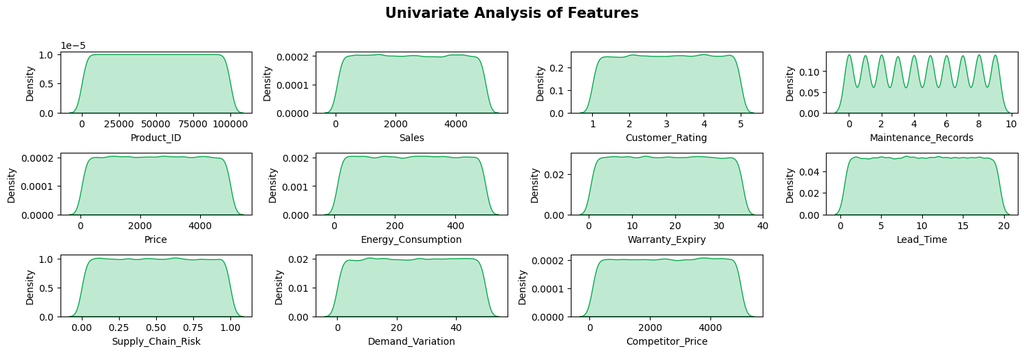

```python
plt.figure(figsize=(15,15))
plt.suptitle('Univariate Analysis of Features',fontweight='bold',fontsize=15,y=1)

for i in range(0,len(num_features)):
    plt.subplot(10,4,i+1)
    sns.kdeplot(x=df[num_features[i]],shade=True,color='#06a94d')
    plt.tight_layout()
```

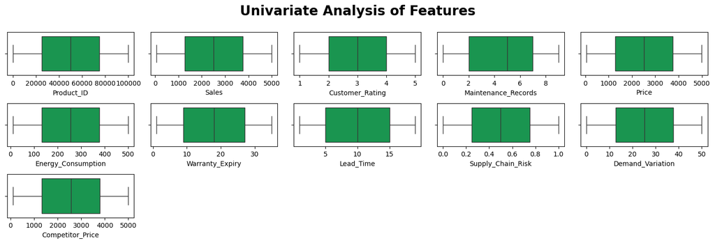

```python
plt.figure(figsize = (15,15))
plt.suptitle('Univariate Analysis of Features',fontweight='bold',fontsize=20,y=1)

for i in range(0,len(num_features)):
    plt.subplot(10,5,i+1)
    sns.boxplot(data=df,x=num_features[i],color='#06a94d')
    plt.xlabel(num_features[i])
    plt.tight_layout()
```

```python
cat_features = df.select_dtypes(include='object').dtypes.index
```

```python
plt.figure(figsize=(15,15))
plt.suptitle('Univariate Analysis of Features',fontweight='bold',fontsize=15,y=1)

for i in range(0,len(cat_features)):
    plt.subplot(10,4,i+1)
    sns.countplot(x=df[cat_features[i]],color='#06a94d')
    plt.tight_layout()
```

[output not shown]

### Feature Preprocessing

```python
# Extract the values for Voltage and Power
df['Voltage'] = df['Technical_Specifications'].apply(lambda x: eval(x)['voltage'].replace('V', ''))
df['Power'] = df['Technical_Specifications'].apply(lambda x: eval(x)['power'].replace('W', ''))
```

```python
# Extract temperature and pressure from the Sensor_Readings column
df['Temperature'] = df['Sensor_Readings'].apply(lambda x: eval(x)['temperature'])
df['Pressure'] = df['Sensor_Readings'].apply(lambda x: eval(x)['pressure'])
```

```python
# Define the mapping function
def map_category(value):
    mapping = {
        "Circuit Breaker": "4",
        "Switch": "3",
        "Busway": "2",
        "Power Meter": "1",
        "Relay": "0"
    }
    return mapping.get(value, "Unknown")  # Default to "Unknown" if value not in mapping


# Apply the mapping function to the Category column
df['Category'] = df['Category'].apply(map_category)
```

```python
# Define the mapping function
def map_fault_flag(value):
    mapping = {
        "Yes": 1,
        "No": 0
    }
    return mapping.get(value, -1)  # Default to -1 if value not in mapping

# Apply the mapping function to the Fault_Flag column
df['Fault_Flag'] = df['Fault_Flag'].apply(map_fault_flag)
```

```python
# Define the mapping function
def map_return_flag(value):
    mapping = {
        "Yes": 1,
        "No": 0
    }
    return mapping.get(value, -1)  # Default to -1 if value not in mapping

# Apply the mapping function to the Return_Flag column
df['Return_Flag'] = df['Return_Flag'].apply(map_return_flag)
```

```python
# Define the mapping function
def map_user_demographics(value):
    mapping = {
        "Individual": 0,
        "Government": 1,
        "Enterprise": 2,
        "Small Business":3
    }
    return mapping.get(value, -1)

df['User_Demographics'] = df['User_Demographics'].apply(map_user_demographics)
```

```python
# Example Machine Learning Use Cases:
```